# Lab 04 - La Quinta is Spanish for next to Denny’s, Pt. 1

Juliet Thistleton

2023-10-12

### Load packages and data

```r
library(tidyverse)
library(here)
library(janitor)
```

```r
states <- read_csv(here("data_raw", "states.csv")) |> clean_names()
dennys <- read_csv(here("data_raw", "dennys.csv")) |> clean_names()
laquinta <- read_csv(here("data_raw", "laquinta.csv")) |> clean_names()
```

### Exercise 1

Finding dimensions of the Denny’s Data set

```r
paste0("Number of Rows: ",nrow(dennys))
```

```
[1] "Number of Rows: 1643"
```

```r
paste0("Number of Columns: ",ncol(dennys))
```

```
[1] "Number of Columns: 6"
```

```r
paste0("Names of Column: ", colnames(dennys))
```

```
[1] "Names of Column: address"   "Names of Column: city"      "Names of Column: state"     "Names of Column: zip"
[5] "Names of Column: longitude" "Names of Column: latitude"
```

Here, we see there are 1643 rows, and 6 columns with the names address, zip, city, longitude, state, and latitude. Each row represents a particular Denny’s, telling its address, zip code, city and state it is located in, and its longitude and latitude.

### Exercise 2

Finding dimensions of the LaQuinta Data set

```r
paste0("Number of Rows: ",nrow(laquinta))
```

```
[1] "Number of Rows: 909"
```

```r
paste0("Number of Columns: ",ncol(laquinta))
```

```
[1] "Number of Columns: 6"
```

```r
paste0("Names of Column: ", colnames(laquinta))
```

```
[1] "Names of Column: address"   "Names of Column: city"      "Names of Column: state"     "Names of Column: zip"
[5] "Names of Column: longitude" "Names of Column: latitude"
```

Here, we see there are 909 rows, and 6 columns with the names address, zip, city, longitude, state, and latitude. Each row represents a particular LaQuinta, telling its address, zip code, city and state it is located in, and its longitude and latitude. ### Exercise 3

### Exercise 4

One way to check if there are any Denny’s are LaQuinta’s outside of the United States is to filter the State row for NA’s or empty space. If there aren’t any empty cells or NA’s, then that indicates that all of the data in the data set comes from establishments within the US. …

### Exercise 5

Filtering for Denny’s outside of the United States

```r
dennys |>
  filter(!(state %in% states$abbreviation))
```

| address | city | state | zip | longitude | latitude |
| --- | --- | --- | --- | --- | --- |

Since there is no data in this tibble, there are no Denny’s outside of the United States in this data Set. ### Exercise 6

Labeling each Denny’s in the United States as in the United States

```r
dennys <- dennys |>
  mutate(country = "United States")
```

### Exercise 7

Filtering for LaQuintas outside of the United States

```r
laquinta |>
  filter(!(state %in% states$abbreviation))
```

| address | city | state | zip | longitude | latitude |
| --- | --- | --- | --- | --- | --- |
| Carretera Panamericana Sur KM 12 | \nAguascalientes | AG | 20345 | -102.27633 | 21.755585 |
| Av. Tulum Mza. 14 S.M. 4 Lote 2 | \nCancun | QR | 77500 | -86.82462 | 21.151911 |
| Ejercito Nacional 8211 | Col\nPartido Iglesias\nJuarez | CH | 32528 | -106.41015 | 31.697130 |
| Blvd. Aeropuerto 4001 | Parque Industrial Interamerican\nApodaca | NL | 66600 | -100.14050 | 25.788750 |
| Carrera 38 # 26-13 Avenida las Palmas con Loma de San Julian El Poblado | \nMedellin Colombia | ANT | 050016 | -75.56551 | 6.224831 |
| AV. PINO SUAREZ No. 1001 | Col. Centro\nMonterrey | NL | 64000 | -100.32011 | 25.666541 |
| Av. Fidel Velazquez #3000 Col. Central | \nMonterrey | NL | 64190 | -100.33770 | 25.720653 |
| 63 King Street East | \nOshawa | ON | L1H1B4 | -78.86126 | 43.898034 |
| Calle Las Torres-1 Colonia Reforma | \nPoza Rica | VE | 93210 | -97.43758 | 20.564131 |
| Blvd. Audi N. 3 Ciudad Modelo | \nSan Jose Chiapa | PU | 75010 | -97.78146 | 19.226297 |

[output cut: 4 more lines]

```r
NA
```

We get 14 locations outside of the United States of America.

### Exercise 8

```r
laquinta <- laquinta |>
  mutate(country = case_when(
    state %in% state.abb     ~ "United States",
    state %in% c("ON", "BC") ~ "Canada",
    state == "ANT"           ~ "Colombia",
    state %in% c("AG", "QR", "CH", "NL", "VE", "PU") ~ "Mexico",
    state == "FM" ~ "Honduras"
  ))
```

Filtering for only LaQuintas inside of the United States

```r
laquinta <- laquinta |>
  filter(country == "United States")
```

### Exercise 9

Finding which state has the most Denny’s.

```r
dennys |>
  group_by(state) |>
  count(state, sort = TRUE)
```

| state | n |
| --- | --- |
| CA | 403 |
| TX | 200 |
| FL | 140 |
| AZ | 83 |
| IL | 56 |
| NY | 56 |
| WA | 49 |
| OH | 44 |
| MO | 42 |
| PA | 40 |

[output cut: 41 more lines]

From this data, it seems that California has the most Denny’s. This is not suprising, as California is home to Los Angeles, San Francisco, and is a prime state for business. The fewest is Deleware. This is unsurprizing, as Deleware is a small state.

Finding the state that has the most LaQuintas

```r
laquinta |>
  group_by(state) |>
  count(state, sort = TRUE)
```

| state | n |
| --- | --- |
| TX | 237 |
| FL | 74 |
| CA | 56 |
| GA | 41 |
| TN | 30 |
| OK | 29 |
| LA | 28 |
| CO | 27 |
| NM | 19 |
| NY | 19 |

[output cut: 38 more lines]

Texas has the most LaQuintas. Texas is a large state, and it does border Mexico, where there are also a lot of LaQuintas. Texas is also a state with many tourists. The state that has the least LaQuintas is Maine. This is unsuprising, as Maine is on the other side of the country than Texas and the south, which seems to be LaQuintas target area of the United States.

### Exercise 10

Joining Denny’s table

```r
dennys |>
  count(state) |>
  inner_join(states, by = c("state" = "abbreviation")) |>
  mutate(per_thousand = (n / area))
```

| state | n | name | area | per_thousand |
| --- | --- | --- | --- | --- |
| AK | 3 | Alaska | 665384.04 | 0.000004508674 |
| AL | 7 | Alabama | 52420.07 | 0.000133536640 |
| AR | 9 | Arkansas | 53178.55 | 0.000169241170 |
| AZ | 83 | Arizona | 113990.30 | 0.000728132131 |
| CA | 403 | California | 163694.74 | 0.002461899509 |
| CO | 29 | Colorado | 104093.67 | 0.000278595231 |
| CT | 12 | Connecticut | 5543.41 | 0.002164732538 |
| DC | 2 | District of Columbia | 68.34 | 0.029265437518 |
| DE | 1 | Delaware | 2488.72 | 0.000401812980 |
| FL | 140 | Florida | 65757.70 | 0.002129028235 |

[output cut: 41 more lines]

Joining LaQuinta’s table

```r
laquinta |>
  group_by(state) |>
  count(state) |>
  inner_join(states, by = c("state" = "abbreviation")) |>
    mutate(per_thousand = (n / area))
```

| state | n | name | area | per_thousand |
| --- | --- | --- | --- | --- |
| AK | 2 | Alaska | 665384.04 | 0.000003005783 |
| AL | 16 | Alabama | 52420.07 | 0.000305226605 |
| AR | 13 | Arkansas | 53178.55 | 0.000244459467 |
| AZ | 18 | Arizona | 113990.30 | 0.000157908173 |
| CA | 56 | California | 163694.74 | 0.000342100180 |
| CO | 27 | Colorado | 104093.67 | 0.000259381766 |
| CT | 6 | Connecticut | 5543.41 | 0.001082366269 |
| FL | 74 | Florida | 65757.70 | 0.001125343496 |
| GA | 41 | Georgia | 59425.15 | 0.000689943568 |
| IA | 4 | Iowa | 56272.81 | 0.000071082286 |

[output cut: 38 more lines]

Identifying Denny’s and LaQuintas

```r
dennys <- dennys |>
  mutate(establishment = "Denny's")
laquinta <- laquinta |>
  mutate(establishment = "La Quinta")
```

Creating a new data frame of both Denny’s and LaQuintas

```r
dn_lq <- bind_rows(dennys, laquinta)
```

Plotting Denny’s to LaQuintas

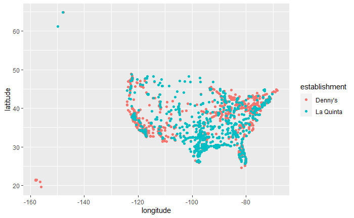

```r
ggplot(dn_lq, mapping = aes(x = longitude, y = latitude, color = establishment)) +
  geom_point(alpha = 100)
```

### Exercise 11

Filtering for just North Carolina

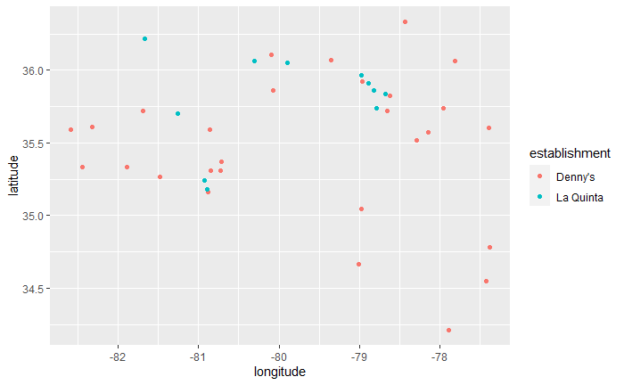

```r
dn_lq |>
  filter(state == "NC") |>
  ggplot(mapping = aes(x = longitude, y = latitude, color = establishment)) +
  geom_point(alpha= 10)
```

Mitch Hedberg’s joke does not appear to hold here.

### Exercise 12

Filtering for just Texas

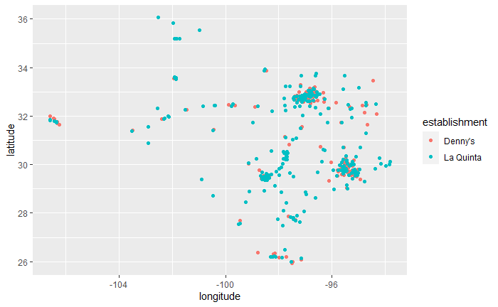

```r
dn_lq |>
  filter(state == "TX") |>
  ggplot(mapping = aes(x = longitude, y = latitude, color = establishment)) +
  geom_point(alpha= 10)
```

While there are more Denny’s near LaQuintas in Texas, the number of LaQuintas next to Denny’s is not significant enough to make such a broad assumption. There are many LaQuintas that are not to Denny’s in the U.S.